## Instalação de Pacotes

```r
# Carregar pacotes
library(tidyverse)
library(GGally)
```

```r
library(corrplot)
library(gridExtra)
```

## 1. Carregamento e Preparação dos Dados base 2023

```r
# 1. Carregamento e Preparação dos Dados
# Carregar os dados
cod_data <- read.csv("C:/Users/Inteli/Downloads/EPA-PONDERADA/2023.csv")

# Exibir as primeiras linhas do data frame
head(cod_data, 10)
```

```
##          data cod_vendedor          cod_loja cod_transacao quantidade
## 1  2023-12-18          398 SP Capital Sul_29    0000199d2b          6
## 2  2023-12-18          398 SP Capital Sul_29    0000199d2b          5
## 3  2023-12-16          914    SP Interior_20    0001204183          2
## 4  2023-12-28          922    SP Interior_36    00037719b1          4
## 5  2023-12-16           41    SP Interior_16    000381d99f          2
## 6  2023-12-20          804              RS_6    0003904d64          6
## 7  2023-12-20          804              RS_6    0003904d64          5
## 8  2023-12-29          943    SP Interior_44    0003b678af          4
## 9  2023-12-20          733              RS_6    00040bba93          5
## 10 2023-12-27          548    SP Interior_61    00046261af          3
##        cod_prod     preco
## 1  589021652592  524.6128
## 2  785392870379 1311.6325
## 3  808856535109  542.7452
## 4  120545844331  124.5948
## 5  630692039998  484.4482
## 6  167150472191  138.6464
## 7   55912326892  216.0507
## 8  866090185962  120.5743
## 9  699457478304  221.0763
## 10 711147737185  171.8455
```

## c) Verificação da estrutura dos dados

```r
# Verificando a estrutura dos dados
str(cod_data)
```

```
## 'data.frame':    10231522 obs. of  7 variables:
##  $ data         : chr  "2023-12-18" "2023-12-18" "2023-12-16" "2023-12-28" ...
##  $ cod_vendedor : int  398 398 914 922 41 804 804 943 733 548 ...
##  $ cod_loja     : chr  "SP Capital Sul_29" "SP Capital Sul_29" "SP Interior_20" "SP Interior_36" ...
##  $ cod_transacao: chr  "0000199d2b" "0000199d2b" "0001204183" "00037719b1" ...
##  $ quantidade   : int  6 5 2 4 2 6 5 4 5 3 ...
##  $ cod_prod     : num  5.89e+11 7.85e+11 8.09e+11 1.21e+11 6.31e+11 ...
##  $ preco        : num  525 1312 543 125 484 ...
```

## 2. Resumo Estatístico e Descrição dos Dados

```r
# Resumo estatístico das variáveis numéricas
summary(cod_data,20)
```

```
##      data            cod_vendedor      cod_loja         cod_transacao
##  Length:10231522    Min.   :   1.0   Length:10231522    Length:10231522
##  Class :character   1st Qu.: 251.0   Class :character   Class :character
##  Mode  :character   Median : 493.0   Mode  :character   Mode  :character
##                     Mean   : 498.9
##                     3rd Qu.: 756.0
##                     Max.   :1000.0
##    quantidade       cod_prod             preco
##  Min.   :1.000   Min.   :6.587e+09   Min.   :  12.72
##  1st Qu.:2.000   1st Qu.:2.528e+11   1st Qu.: 102.95
##  Median :4.000   Median :5.292e+11   Median : 202.30
##  Mean   :3.649   Mean   :5.167e+11   Mean   : 360.96
##  3rd Qu.:5.000   3rd Qu.:7.892e+11   3rd Qu.: 391.60
##  Max.   :8.000   Max.   :9.970e+11   Max.   :4303.16
```

Descrição clara das variáveis no dataset:

- **data**: Data da transação.
- **cod_vendedor**: Código do vendedor.
- **cod_loja**: Código da loja onde ocorreu a venda.
- **cod_transacao**: Código único da transação.
- **quantidade**: Quantidade de produtos vendidos.
- **cod_prod**: Código do produto.
- **preco**: Preço do produto.

## 3. Análise Univariada

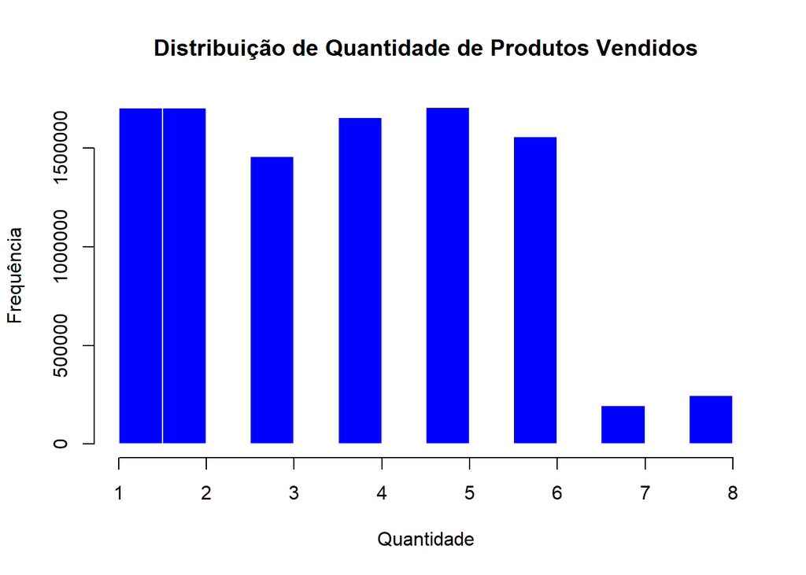

```r
# Histograma da variável 'quantidade'
hist(cod_data$quantidade,
     main = "Distribuição de Quantidade de Produtos Vendidos",
     xlab = "Quantidade",  # Rótulo do eixo X
     ylab = "Frequência",  # Rótulo do eixo Y
     col = "blue",  # Cor das barras
     border = "white")  # Cor das bordas das barras
```

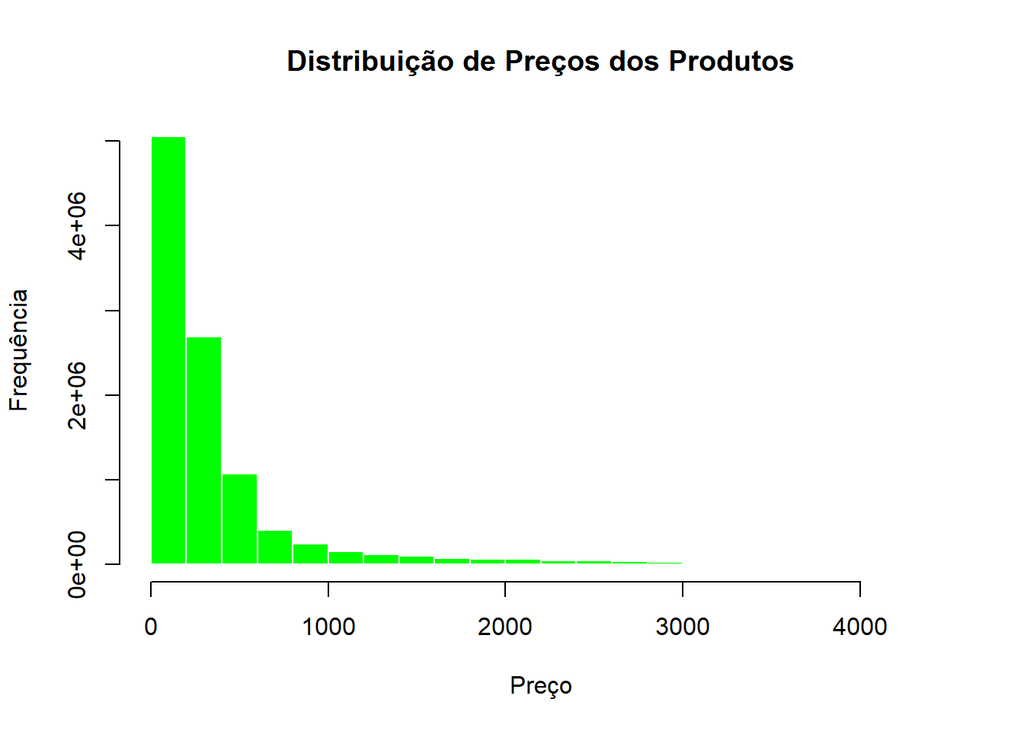

```r
# Histograma da variável 'preco'
hist(cod_data$preco,
     main = "Distribuição de Preços dos Produtos",
     xlab = "Preço",  # Rótulo do eixo X
     ylab = "Frequência",  # Rótulo do eixo Y
     col = "green",  # Cor das barras
     border = "white")  # Cor das bordas das barras
```

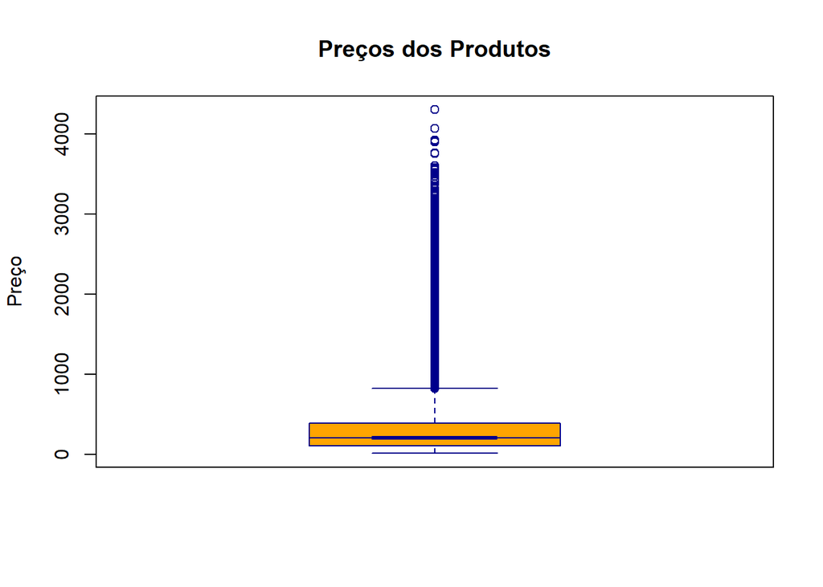

```r
# Boxplot da variável 'preco'
boxplot(cod_data$preco,
        main = "Preços dos Produtos",  # Título do gráfico
        ylab = "Preço",  # Rótulo do eixo Y
        col = "orange",  # Cor do boxplot
        border = "darkblue",  # Cor da borda do boxplot
        notch = TRUE)  # Adiciona uma entalhe para indicar o intervalo de confiança da mediana
```

## b) Identificação de outliers

```r
# Função para identificar outliers usando a regra do IQR
identifica_outliers <- function(x) {
  Q1 <- quantile(x, 0.25)
  Q3 <- quantile(x, 0.75)
  IQR <- Q3 - Q1
  lower_bound <- Q1 - 1.5 * IQR
  upper_bound <- Q3 + 1.5 * IQR
  outliers <- x[x < lower_bound | x > upper_bound]
  return(outliers)
}

# Identificação de outliers para a variável 'preco'
outliers_preco <- identifica_outliers(cod_data$preco)
print("Outliers identificados na variável 'preco':")
```

```
## [1] "Outliers identificados na variável 'preco':"
```

```r
print(head(outliers_preco, 10))
```

```
##  [1] 1311.6325 2014.2221 1103.5926 1347.8370 1370.9447  914.6098 1661.4347
##  [8] 1356.8630 1140.7620  826.1491
```

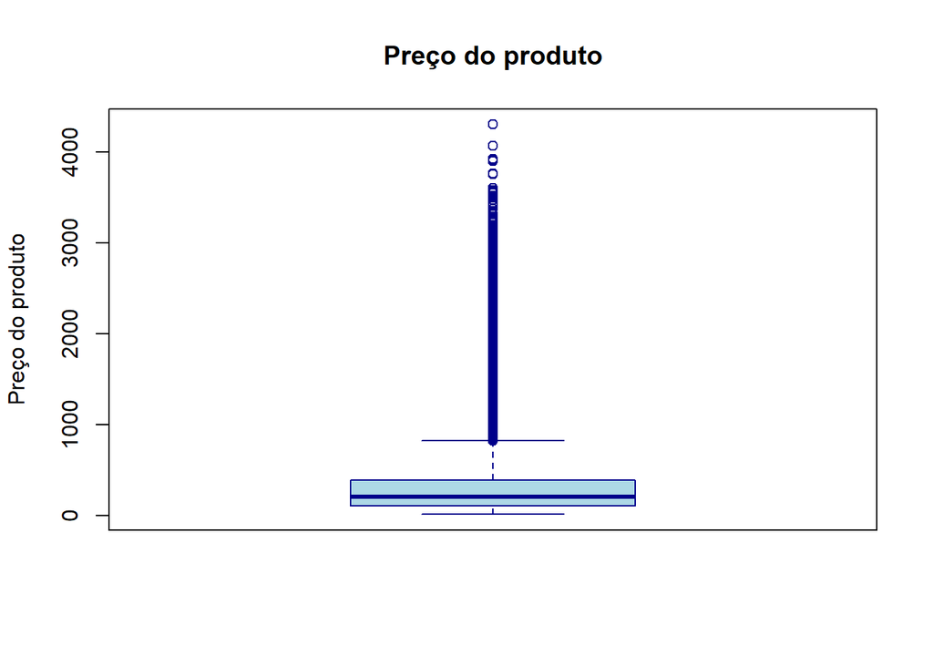

```r
# Boxplot para 'preco'
boxplot(cod_data$preco,
        main = "Preço do produto",
        ylab = "Preço do produto",
        col = "lightblue",
        border = "darkblue",
        outline = TRUE)  # Exibe outliers
```

```r
# Identificação de outliers para a variável 'quantidade'
outliers_quantidade <- identifica_outliers(cod_data$quantidade)
print("Outliers identificados na variável 'quantidade':")
```

```
## [1] "Outliers identificados na variável 'quantidade':"
```

```r
print(head(outliers_quantidade, 10))
```

```
## integer(0)
```

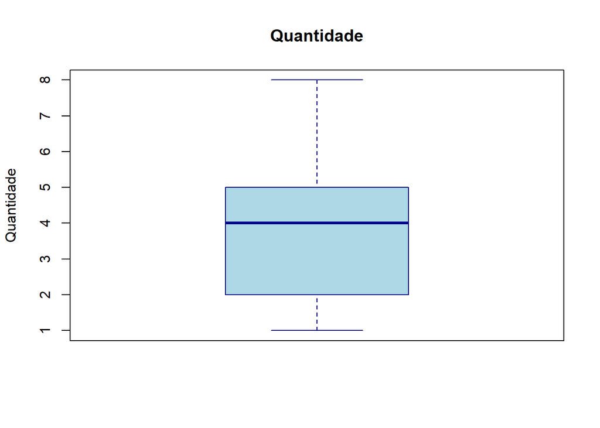

```r
# Boxplot para 'quantidade'
boxplot(cod_data$quantidade,
        main = " Quantidade ",
        ylab = "Quantidade",
        col = "lightblue",
        border = "darkblue",
        outline = TRUE)  # Exibe outliers
```

## 4. Análise Bivariada

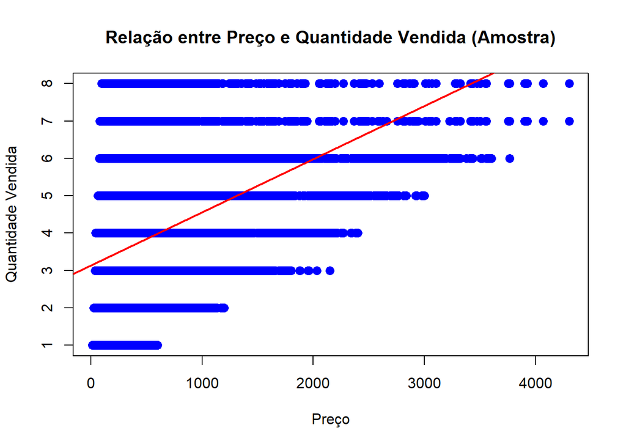

```r
set.seed(123)  # Para reprodutibilidade
sample_size <- floor(0.1 * nrow(cod_data))  # Tamanho da amostra (10% dos dados)
sample_indices <- sample(seq_len(nrow(cod_data)), size = sample_size)  # Índices da amostra
cod_data_sample <- cod_data[sample_indices, ]  # Criando o dataframe amostrado

# Scatter plot entre 'preco' e 'quantidade' com a amostra
plot(cod_data_sample$preco,
     cod_data_sample$quantidade,
     main = "Relação entre Preço e Quantidade Vendida (Amostra)",
     xlab = "Preço",
     ylab = "Quantidade Vendida",
     col = "blue",
     pch = 16,  # Forma dos pontos
     cex = 1.3)  # Tamanho dos pontos

# Adicionando uma linha de tendência
abline(lm(cod_data_sample$quantidade ~ cod_data_sample$preco), col = "red", lwd = 2)
```

## b) Análise de correlação

```r
# Matriz de correlação
cor_matrix <- cor(cod_data[, c("quantidade", "preco")])
cor_matrix
```

```
##            quantidade     preco
## quantidade  1.0000000 0.3682646
## preco       0.3682646 1.0000000
```

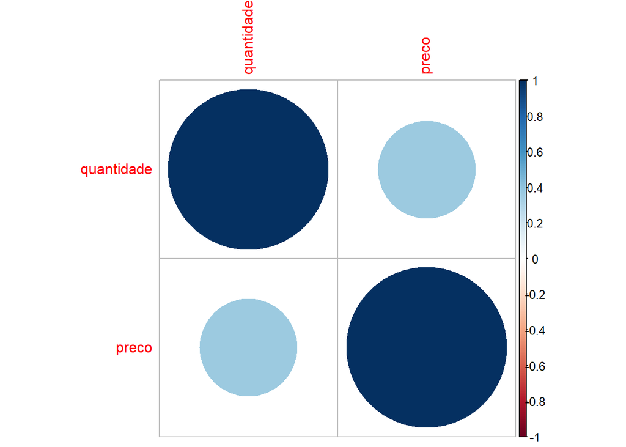

```r
# Visualização da correlação
library(corrplot)
corrplot(cor_matrix, method = "circle")
```

## 5. Análise Multivariada

## a) Análise de Componentes Principais (PCA)

## Implementação de PCA:

```r
set.seed(100)  # Para reprodutibilidade
sample_size <- floor(0.1 * nrow(cod_data))  # Tamanho da amostra (10% dos dados)
sample_indices <- sample(seq_len(nrow(cod_data)), size = sample_size)  # Índices da amostra
df_sample <- cod_data[sample_indices, ]  # Criando o dataframe amostrado
pca_result <- prcomp(df_sample[, c("quantidade", "preco")], scale. = TRUE)
summary(pca_result)
```

```
## Importance of components:
##                           PC1    PC2
## Standard deviation     1.1697 0.7949
## Proportion of Variance 0.6841 0.3159
## Cumulative Proportion  0.6841 1.0000
```

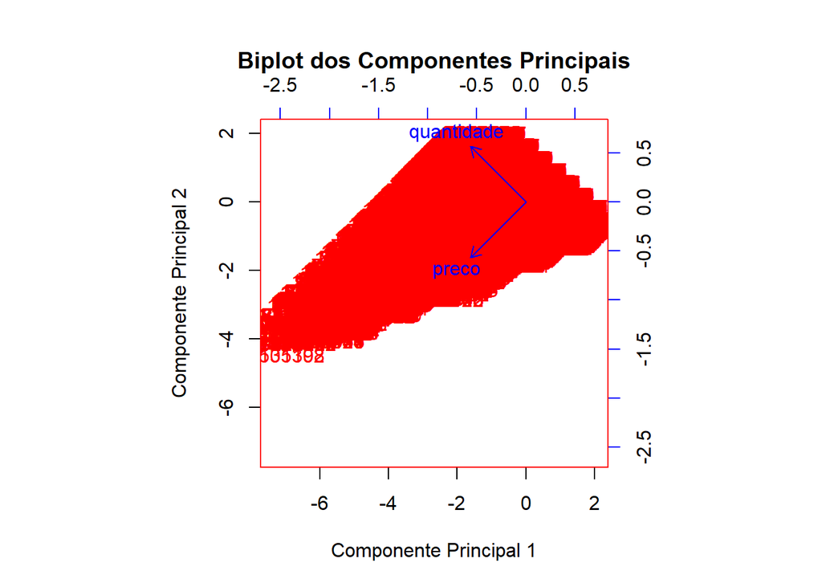

```r
biplot(pca_result, scale = 0,
       main = "Biplot dos Componentes Principais",
       xlab = "Componente Principal 1",
       ylab = "Componente Principal 2",
       col = c("red", "blue"))
```

## 6. Conclusão e Discussão

## a) Sumário das descobertas

Um sumário das principais descobertas:

- A variável **preco** mostrou-se mais dispersa, com alguns outliers significativos.
- A correlação entre **quantidade** e **preco** foi moderada.
- O PCA revelou que a maior parte da variância é explicada pelo primeiro componente.

## b) Discussão sobre limitações e possíveis melhorias

Limitações e melhorias:

- A análise foi limitada à variáveis numéricas, sem considerar outras variáveis categóricas.
- Sugere-se a aplicação de técnicas de clustering ou regressão para análises futuras.